# Práctica 9. Reconstrucción filogenética

Author

Ismael Rodrigo Puerto

# Preparación

Necesitamos tener instalado el paquete phangorn de R. En el ordenador virtual ya está instalado.

# Objetivos

Obtener una filogenia calibrada de homininos y algunos primates, a partir de secuencias mitocondriales.

# Datos

Pinchando aquí descargaréis un alineamiento en formato FASTA de 42 cromosomas mitocondriales completos de: un gorila, cuatro chimpancés, cuatro bonobos, un Homo heidelbergensis (de hace unos 400000 años), 4 humanos denisovanos (de hace entre 30000 y 110000 años), 19 humanos neandertales (de hace entre 30000 y 180000 años) y 9 humanos anatómicamente modernos (actuales). Tal vez también encontréis el archivo en el aula virtual, con el nombre mtDNA.fasta.

## Ejercicio 1

# Leer los datos en R

```r
library(phangorn)
mtdna <- read.phyDat('mtDNA.fasta', format = 'fasta')
glance(mtdna)
```

```
  nseq nchar unique_site_pattern parsimony_informative_sites const_sites
1   42 16603                 974                        2047       13482
```

*Sería sensato reducir el conjunto de datos. ¿Qué secuencias eliminarías? Si quieres, puedes intentarlo con la función subset().*

# Escoger el modelo de evolución

Evaluar los 92 modelos posibles puede llevar un rato…

```r
modelos <- modelTest(mtdna, control = pml.control(trace = 0))
```

```r
fit <- as.pml(modelos, 'BIC')
show(fit)
```

```
model: TIM2+G(4)+I
loglikelihood: -44351.3
unconstrained loglikelihood: -45918.42
Proportion of invariant sites: 0.611973
Model of rate heterogeneity: Discrete gamma model
Number of rate categories: 4
Shape parameter: 0.9223893
      Rate Proportion
1 0.000000 0.61197296
2 0.312401 0.09700676
3 1.165159 0.09700676
4 2.540667 0.09700676
5 6.290333 0.09700676

Rate matrix:
          a         c        g         t
a  0.000000  2.135842 66.51748  2.135842
c  2.135842  0.000000  1.00000 54.136216
g 66.517477  1.000000  0.00000  1.000000
t  2.135842 54.136216  1.00000  0.000000

Base frequencies:
        a         c         g         t
0.3093660 0.3113173 0.1307058 0.2486109
```

```r
#Permite seleccionar el mejor modelo en base al criterio de BIC. También se puede poner el criterio AIC o especificar un modelo y que te dé los resultados de ese en concreto.
#Este objeto fit se puede usar después porque tiene escondida la información del alineamiento.
```

Si tienes más de un procesador (y si tienes el paquete parallel instalado), puedes pedirle que los use:

```r
modelos <- modelTest(mtdna, control = pml.control(trace = 0),
                     multicore = TRUE, mc.cores = 2)
```

Si no has tenido paciencia para dejar que termine la búsqueda, puedes usar el modelo más complejo: GTR+G(4)+I, porque la cantidad de datos lo permite, aunque en realidad el modelo con menor BIC es otro.

# NJ y UPGMA

La función dist.ml() de phangorn solo permite usar distancias de Juke Cantor y de Felsenstein 1981 con ADN. Para usar otros modelos, debemos usar la función dist.dna() del paquete ape (automáticamente cargado con phangorn), que se aplica a objetos de clase DNAbin. Por eso, usamos la función as.DNAbin() para presentarle a dist.dna() los datos en el formato adecuado. En cualquier caso, dist.dna() tampoco implementa todos los modelos.

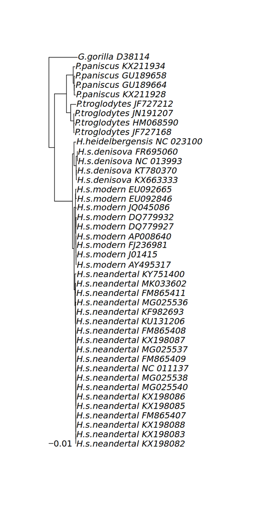

```r
mt_nj    <-    NJ(dist.dna(as.DNAbin(mtdna), model = 'TN93', gamma = 0.93))
mt_upgma <- upgma(dist.dna(as.DNAbin(mtdna), model = 'TN93', gamma = 0.93))
plot(midpoint(mt_nj))
add.scale.bar()
```

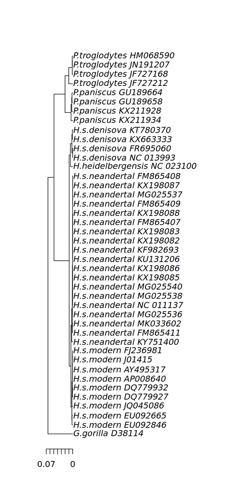

```r
plot(mt_upgma)
axisPhylo()
```

Parece que no está implementado para el TIM2+G(4)+I, por lo que lo ejecutamos con TN93 aunque no sea el que mejor BIC tiene *Cuando la función plot() se aplica a un objeto de clase phylo, en realidad se ejecuta la función plot.phylo(). Si quieres explorar las opciones de representación gráfica de árboles con plot(), consulta help(plot.phylo).*

*¿Por qué usamos midpoint() al representar gráficamente el árbol de NJ?* Porque los árboles generados por NJ no se enraizan, por ello añadimos midpoint para enraizar el árbol en el punto medio. **Podemos enraizar el árbol**

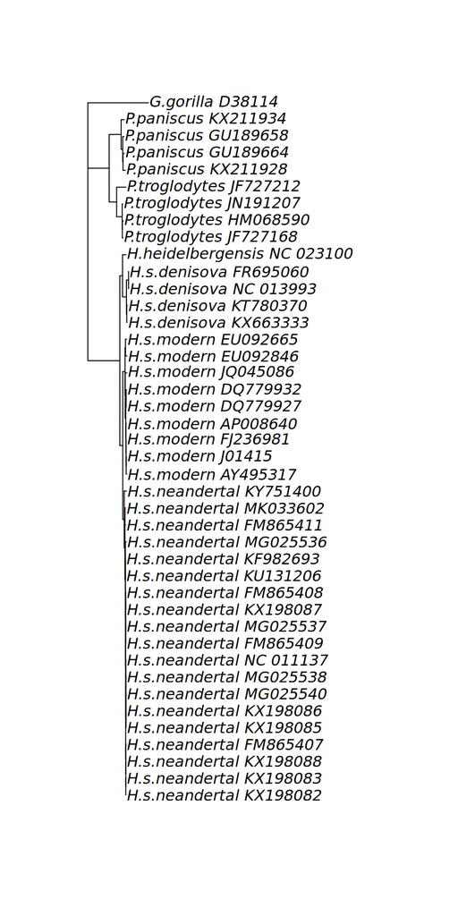

```r
enraizado <- root(mt_nj, 'G.gorilla_D38114')
plot(enraizado)
```

# Máxima verosimilitud

```r
veros <- pml_bb(mtdna, model = 'GTR+G(4)+I',
                control = pml.control(trace = 0))
```

El objeto veros, de clase pml, contiene el árbol (veros$tree), además de los parámetros optimizados del modelo. Podemos enraizar el árbol usando al gorila como outgroup:

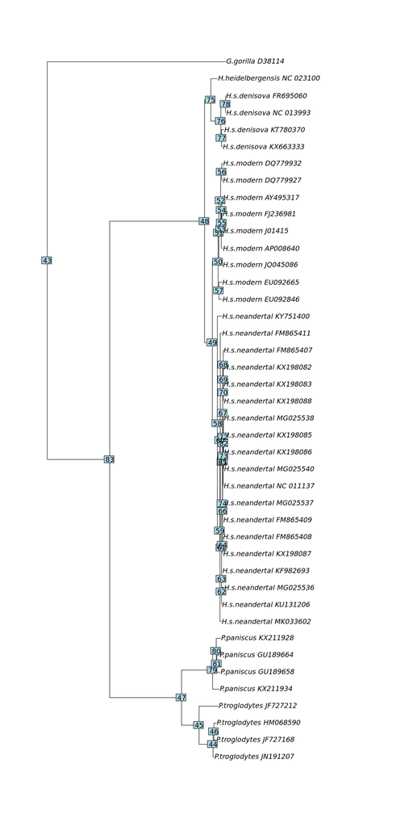

```r
mt_ml <- root(veros$tree, 'G.gorilla_D38114')
plot(midpoint(mt_ml))
nodelabels()
```

```r
#Hacemos un segundo veros2 para fit para hacerlo con nuestro modelo con mejor BIC TIM2+G(4)+I
veros2 <- pml_bb(fit,
                control = pml.control(trace = 0))
```

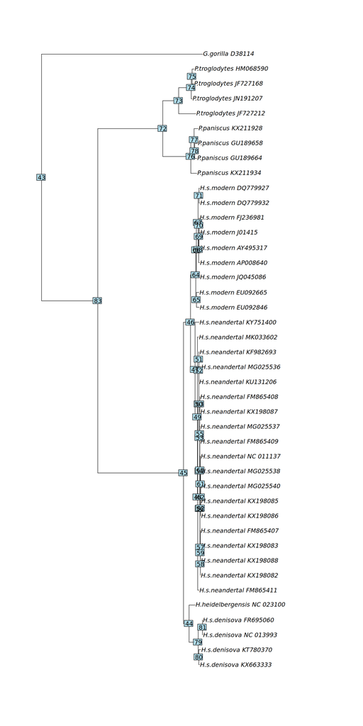

```r
mt_ml2 <- root(veros2$tree, 'G.gorilla_D38114')
plot(midpoint(mt_ml2))
nodelabels()
```

También podemos extraer un subárbol para visualizarlo mejor. Con nodelabels() identifico fácilmente cual es el nodo en el que quiero recortar el árbol:

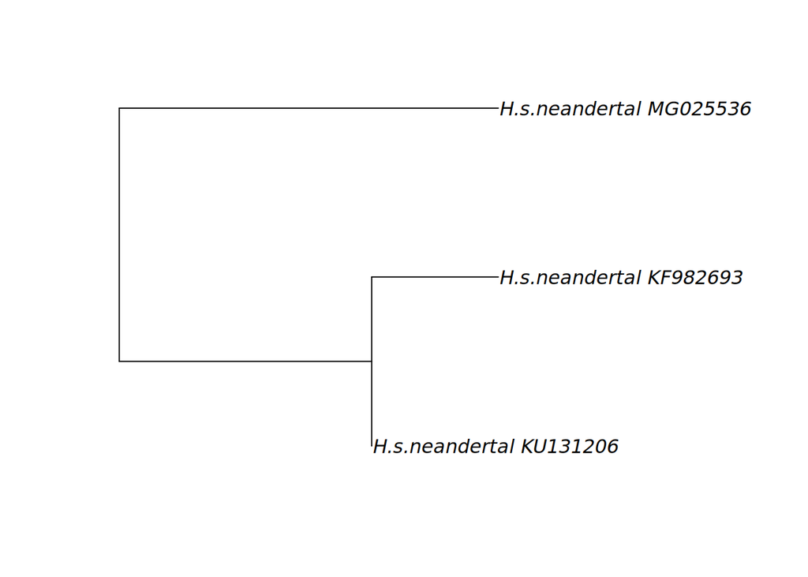

```r
homo <- extract.clade(mt_ml, 62)
plot(midpoint(homo))
```

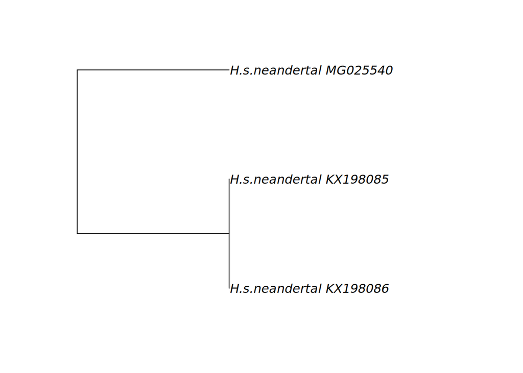

```r
homo2 <- extract.clade(mt_ml2, 62)
plot(midpoint(homo2))
```